# cc_profit_analysis_revised

**Project Overview**

This notebook presents the project team’s analysis of customer profitability, focusing on customers flagged as “in need of attention.” By linking profitability outcomes to risk detection, the team quantifies potential financial exposure and highlights opportunities for preventive interventions.

**Objectives:**

- Assess profitability status of at-risk customers
- Quantify potential profit loss exposure
- Evaluate the financial impact of predictive risk detection
- Support decision-making for loss prevention and customer engagement strategies

|  | cust_id | balance | balance_frequency | purchases | oneoff_purchases | installments_purchases | cash_advance | purchases_frequency | oneoff_purchases_frequency | purchases_installments_frequency | cash_advance_frequency | cash_advance_trx | purchases_trx | credit_limit | payments | minimum_payments | prc_full_payment | tenure | cluster | customer_segment | utilization | min_pay_ratio | flag_cash_advance | flag_low_payment | flag_high_util | flag_min_only | flag_irregular_balance | stress_score | risk_level | … |
| --- | --- | --- | --- | --- | --- | --- | --- | --- | --- | --- | --- | --- | --- | --- | --- | --- | --- | --- | --- | --- | --- | --- | --- | --- | --- | --- | --- | --- | --- | --- |
| 0 | C10001 | 40.900749 | 0.818182 | 95.40 | 0.00 | 95.4 | 0.000000 | 0.166667 | 0.000000 | 0.083333 | 0.000000 | 0 | 2 | 1000.0 | 201.802084 | 139.509787 | 0.000000 | 12 | 6 | Dormant / Casual Users | 0.040901 | 0.691320 | False | True | False | False | False | 1 | low | … |
| 1 | C10002 | 3202.467416 | 0.909091 | 0.00 | 0.00 | 0.0 | 6442.945483 | 0.000000 | 0.000000 | 0.000000 | 0.250000 | 4 | 0 | 7000.0 | 4103.032597 | 1072.340217 | 0.222222 | 12 | 0 | Heavy Credit Users (Revolvers) | 0.457495 | 0.261353 | False | True | False | False | False | 1 | low | … |
| 2 | C10003 | 2495.148862 | 1.000000 | 773.17 | 773.17 | 0.0 | 0.000000 | 1.000000 | 1.000000 | 0.000000 | 0.000000 | 0 | 12 | 7500.0 | 622.066742 | 627.284787 | 0.000000 | 12 | 2 | Balanced Moderate Spenders | 0.332687 | 1.008388 | False | True | False | True | False | 2 | low | … |
| 3 | C10004 | 1666.670542 | 0.636364 | 1499.00 | 1499.00 | 0.0 | 205.788017 | 0.083333 | 0.083333 | 0.000000 | 0.083333 | 1 | 1 | 7500.0 | 0.000000 | 312.343947 | 0.000000 | 12 | 6 | Dormant / Casual Users | 0.222223 | 0.000000 | False | True | False | False | False | 1 | low | … |
| 4 | C10005 | 817.714335 | 1.000000 | 16.00 | 16.00 | 0.0 | 0.000000 | 0.083333 | 0.083333 | 0.000000 | 0.000000 | 0 | 1 | 1200.0 | 678.334763 | 244.791237 | 0.000000 | 12 | 6 | Dormant / Casual Users | 0.681429 | 0.360871 | False | True | True | False | False | 2 | low | … |

|  | cust_id | balance | balance_frequency | purchases | oneoff_purchases | installments_purchases | cash_advance | purchases_frequency | oneoff_purchases_frequency | purchases_installments_frequency | cash_advance_frequency | cash_advance_trx | purchases_trx | credit_limit | payments | minimum_payments | prc_full_payment | tenure | cluster | customer_segment | utilization | min_pay_ratio | flag_cash_advance | flag_low_payment | flag_high_util | flag_min_only | flag_irregular_balance | stress_score | risk_level | … |
| --- | --- | --- | --- | --- | --- | --- | --- | --- | --- | --- | --- | --- | --- | --- | --- | --- | --- | --- | --- | --- | --- | --- | --- | --- | --- | --- | --- | --- | --- | --- |
| 0 | C10001 | 40.900749 | 0.818182 | 95.40 | 0.00 | 95.4 | 0.000000 | 0.166667 | 0.000000 | 0.083333 | 0.000000 | 0 | 2 | 1000.0 | 201.802084 | 139.509787 | 0.000000 | 12 | 6 | Dormant / Casual Users | 0.040901 | 0.691320 | False | True | False | False | False | 1 | low | … |
| 1 | C10002 | 3202.467416 | 0.909091 | 0.00 | 0.00 | 0.0 | 6442.945483 | 0.000000 | 0.000000 | 0.000000 | 0.250000 | 4 | 0 | 7000.0 | 4103.032597 | 1072.340217 | 0.222222 | 12 | 0 | Heavy Credit Users (Revolvers) | 0.457495 | 0.261353 | False | True | False | False | False | 1 | low | … |
| 2 | C10003 | 2495.148862 | 1.000000 | 773.17 | 773.17 | 0.0 | 0.000000 | 1.000000 | 1.000000 | 0.000000 | 0.000000 | 0 | 12 | 7500.0 | 622.066742 | 627.284787 | 0.000000 | 12 | 2 | Balanced Moderate Spenders | 0.332687 | 1.008388 | False | True | False | True | False | 2 | low | … |
| 3 | C10004 | 1666.670542 | 0.636364 | 1499.00 | 1499.00 | 0.0 | 205.788017 | 0.083333 | 0.083333 | 0.000000 | 0.083333 | 1 | 1 | 7500.0 | 0.000000 | 312.343947 | 0.000000 | 12 | 6 | Dormant / Casual Users | 0.222223 | 0.000000 | False | True | False | False | False | 1 | low | … |
| 4 | C10005 | 817.714335 | 1.000000 | 16.00 | 16.00 | 0.0 | 0.000000 | 0.083333 | 0.083333 | 0.000000 | 0.000000 | 0 | 1 | 1200.0 | 678.334763 | 244.791237 | 0.000000 | 12 | 6 | Dormant / Casual Users | 0.681429 | 0.360871 | False | True | True | False | False | 2 | low | … |

```
count     8950.000000
mean      -820.573046
std       3910.087029
min     -68666.727520
25%      -1630.174721
50%       -150.952501
75%        487.997140
max      45507.333693
Name: profit_proxy, dtype: float64
```

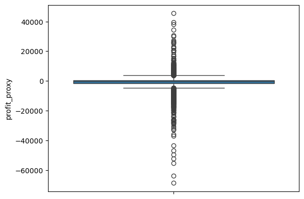

```
0
```

|  | cust_id | balance | balance_frequency | purchases | oneoff_purchases | installments_purchases | cash_advance | purchases_frequency | oneoff_purchases_frequency | purchases_installments_frequency | cash_advance_frequency | cash_advance_trx | purchases_trx | credit_limit | payments | minimum_payments | prc_full_payment | tenure | cluster | customer_segment | utilization | min_pay_ratio | flag_cash_advance | flag_low_payment | flag_high_util | flag_min_only | flag_irregular_balance | stress_score | risk_level | … |
| --- | --- | --- | --- | --- | --- | --- | --- | --- | --- | --- | --- | --- | --- | --- | --- | --- | --- | --- | --- | --- | --- | --- | --- | --- | --- | --- | --- | --- | --- | --- |
| 0 | C10001 | 40.900749 | 0.818182 | 95.40 | 0.00 | 95.4 | 0.000000 | 0.166667 | 0.000000 | 0.083333 | 0.000000 | 0 | 2 | 1000.0 | 201.802084 | 139.509787 | 0.000000 | 12 | 6 | Dormant / Casual Users | 0.040901 | 0.691320 | False | True | False | False | False | 1 | low | … |
| 1 | C10002 | 3202.467416 | 0.909091 | 0.00 | 0.00 | 0.0 | 6442.945483 | 0.000000 | 0.000000 | 0.000000 | 0.250000 | 4 | 0 | 7000.0 | 4103.032597 | 1072.340217 | 0.222222 | 12 | 0 | Heavy Credit Users (Revolvers) | 0.457495 | 0.261353 | False | True | False | False | False | 1 | low | … |
| 2 | C10003 | 2495.148862 | 1.000000 | 773.17 | 773.17 | 0.0 | 0.000000 | 1.000000 | 1.000000 | 0.000000 | 0.000000 | 0 | 12 | 7500.0 | 622.066742 | 627.284787 | 0.000000 | 12 | 2 | Balanced Moderate Spenders | 0.332687 | 1.008388 | False | True | False | True | False | 2 | low | … |
| 3 | C10004 | 1666.670542 | 0.636364 | 1499.00 | 1499.00 | 0.0 | 205.788017 | 0.083333 | 0.083333 | 0.000000 | 0.083333 | 1 | 1 | 7500.0 | 0.000000 | 312.343947 | 0.000000 | 12 | 6 | Dormant / Casual Users | 0.222223 | 0.000000 | False | True | False | False | False | 1 | low | … |
| 4 | C10005 | 817.714335 | 1.000000 | 16.00 | 16.00 | 0.0 | 0.000000 | 0.083333 | 0.083333 | 0.000000 | 0.000000 | 0 | 1 | 1200.0 | 678.334763 | 244.791237 | 0.000000 | 12 | 6 | Dormant / Casual Users | 0.681429 | 0.360871 | False | True | True | False | False | 2 | low | … |

|  | cust_id | balance | balance_frequency | purchases | oneoff_purchases | installments_purchases | cash_advance | purchases_frequency | oneoff_purchases_frequency | purchases_installments_frequency | cash_advance_frequency | cash_advance_trx | purchases_trx | credit_limit | payments | minimum_payments | prc_full_payment | tenure | cluster | customer_segment | utilization | min_pay_ratio | flag_cash_advance | flag_low_payment | flag_high_util | flag_min_only | flag_irregular_balance | stress_score | risk_level | … |
| --- | --- | --- | --- | --- | --- | --- | --- | --- | --- | --- | --- | --- | --- | --- | --- | --- | --- | --- | --- | --- | --- | --- | --- | --- | --- | --- | --- | --- | --- | --- |
| 0 | C10001 | 40.900749 | 0.818182 | 95.40 | 0.00 | 95.4 | 0.000000 | 0.166667 | 0.000000 | 0.083333 | 0.000000 | 0 | 2 | 1000.0 | 201.802084 | 139.509787 | 0.000000 | 12 | 6 | Dormant / Casual Users | 0.040901 | 0.691320 | False | True | False | False | False | 1 | low | … |
| 1 | C10002 | 3202.467416 | 0.909091 | 0.00 | 0.00 | 0.0 | 6442.945483 | 0.000000 | 0.000000 | 0.000000 | 0.250000 | 4 | 0 | 7000.0 | 4103.032597 | 1072.340217 | 0.222222 | 12 | 0 | Heavy Credit Users (Revolvers) | 0.457495 | 0.261353 | False | True | False | False | False | 1 | low | … |
| 2 | C10003 | 2495.148862 | 1.000000 | 773.17 | 773.17 | 0.0 | 0.000000 | 1.000000 | 1.000000 | 0.000000 | 0.000000 | 0 | 12 | 7500.0 | 622.066742 | 627.284787 | 0.000000 | 12 | 2 | Balanced Moderate Spenders | 0.332687 | 1.008388 | False | True | False | True | False | 2 | low | … |
| 3 | C10004 | 1666.670542 | 0.636364 | 1499.00 | 1499.00 | 0.0 | 205.788017 | 0.083333 | 0.083333 | 0.000000 | 0.083333 | 1 | 1 | 7500.0 | 0.000000 | 312.343947 | 0.000000 | 12 | 6 | Dormant / Casual Users | 0.222223 | 0.000000 | False | True | False | False | False | 1 | low | … |
| 4 | C10005 | 817.714335 | 1.000000 | 16.00 | 16.00 | 0.0 | 0.000000 | 0.083333 | 0.083333 | 0.000000 | 0.000000 | 0 | 1 | 1200.0 | 678.334763 | 244.791237 | 0.000000 | 12 | 6 | Dormant / Casual Users | 0.681429 | 0.360871 | False | True | True | False | False | 2 | low | … |

Our team prioritized the analysis of customer profitability, focusing specifically on those flagged as “in need of attention.” This ensures that we understand not only customer risk but also the associated financial impact to the bank.

| profit_status | profit_status_count |
| --- | --- |
| not profitable | 2251 |
| profitable | 161 |

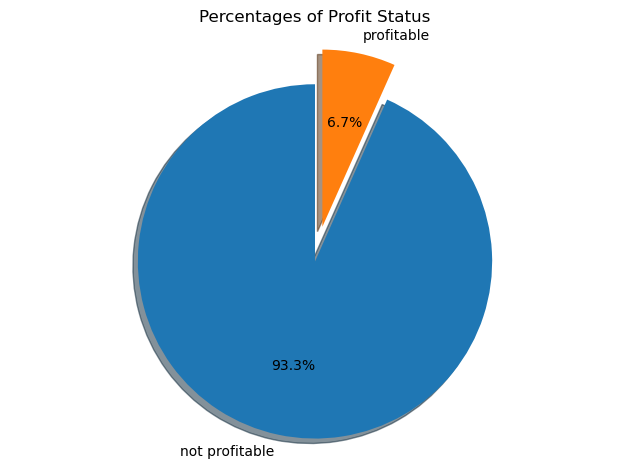

The majority of customers requiring attention were found to be **unprofitable** to the bank. The team therefore assessed the potential **total profit loss exposure**, quantifying the risk in financial terms to better inform strategic interventions.

```
The total potential loss: $7523028.18
```

Through the deployment of a predictive risk detection model, the team identified opportunities to implement **preventive measures**. If acted upon, these measures could potentially mitigate losses of approximately **$7.52 million**, safeguarding profitability while addressing at-risk customers.